# Midterm Prep

Author: Matthew J. Crossley

Last update: 04 April, 2022

## PDF

### Practice 1

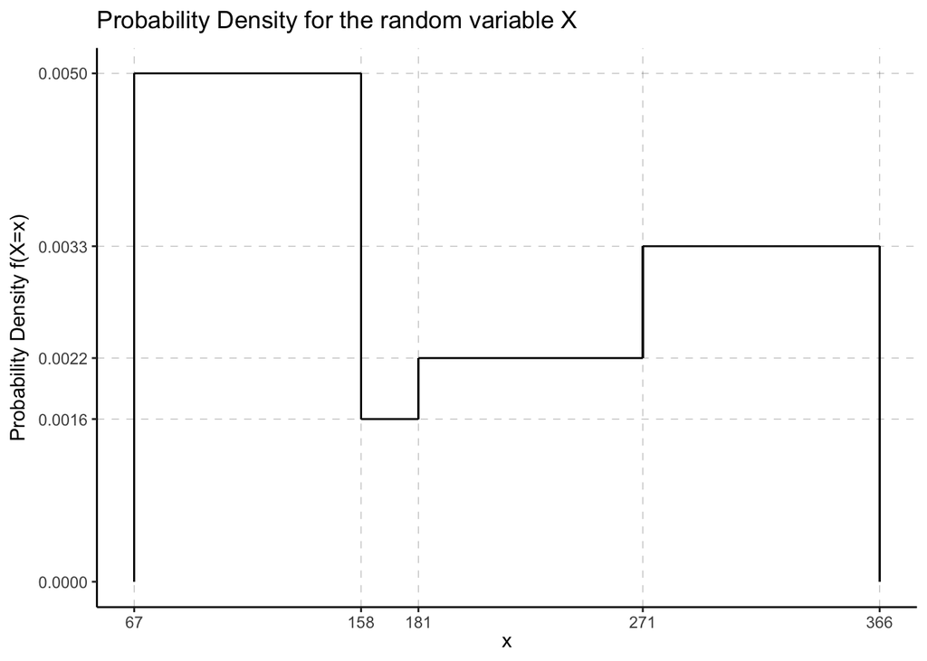

- Is $X$ continuous or discrete?
- Compute $P(X < 181)$
- Compute $P(X > 181)$
- Compute $P(67 \leq X < 181)$
- Find $x$ such that $P(X < x) = 0.05$
- Find $x$ such that $P(X > x) = 0.05$

### Practice 2

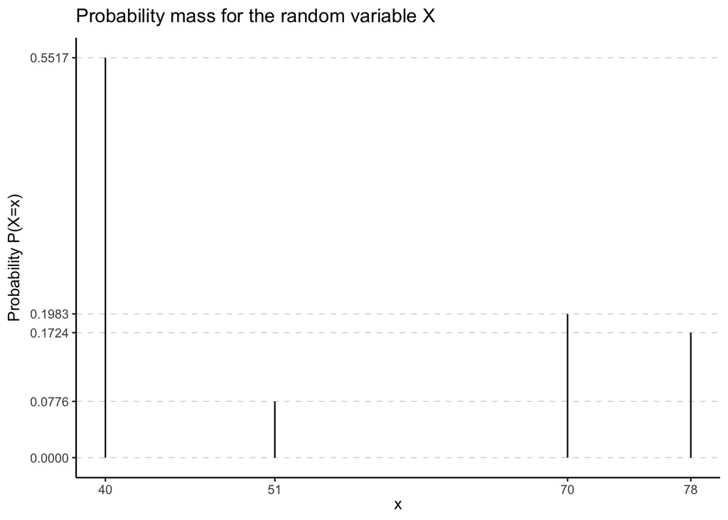

- Is $X$ continuous or discrete?
- Compute $P(X < 70)$
- Compute $P(X > 70)$
- Compute $P(40 \leq X < 70)$
- Compute the mean and variance of $X$

## CDF

### Practice 1

For the random variable $X \sim N(\mu_X=10, \sigma_X=2)$

- Compute $P(X < 12)$
- Compute $P(X > 8)$
- Compute $P(8 \leq X < 12)$

### Practice 2

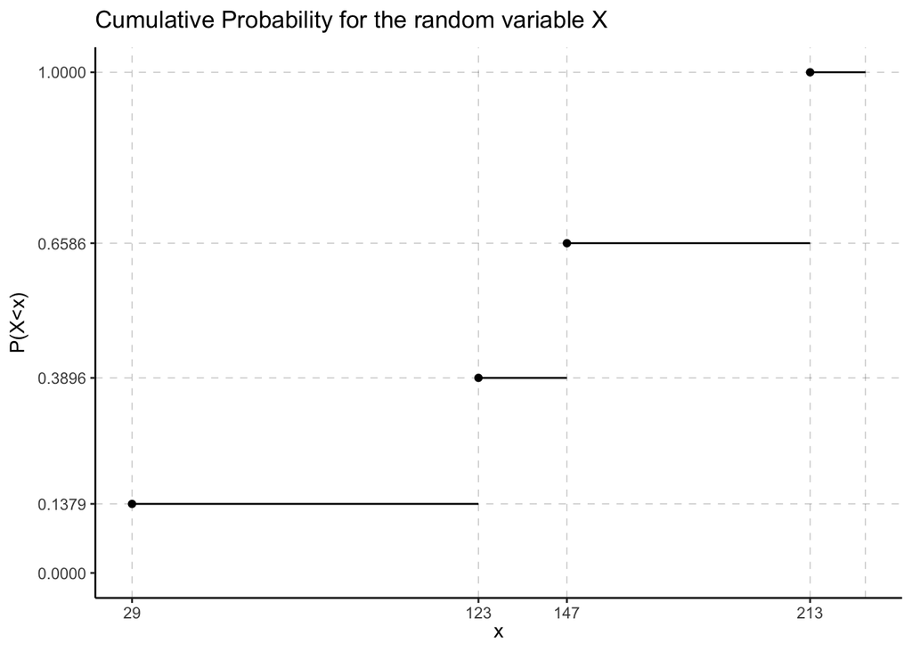

- Is $X$ continuous or discrete?
- Compute $P(X < 123)$
- Compute $P(X \geq 123)$
- Compute $P(123 \leq X < 147)$

## Quantile Function

### Practice 1

For the random variable $X \sim \mathcal{N}(\mu_x = 5, \sigma_x=3)$

- Find $x$ such that $P(X < x) = 0.5$
- Find $x$ such that $P(X < x) = 0.05$
- Find $x$ such that $P(X \geq x) = 0.05$

### Practice 2

For the random variable $X \sim \mathcal{Poisson}(\lambda=4)$

- Find $x$ such that $P(X \leq x) = 0.5$
- Find $x$ such that $P(X < x) = 0.05$
- Find $x$ such that $P(X > x) = 0.05$

## NHST

### Practice 1

Consider an experiment in which participants first learn novel categories, and are subsequently asked to perform some other task. The question the researchers are interested in is how initial learning affects the subsequent task, and it is therefore critical that participants that didn’t learn anything be excluded from the final analysis. An exclusion criteria is set such that any participant that fails to reach at least $60\%$ accuracy by the end of training is excluded. Suppose that data is collected from 30 participants, and of these, 5 are excluded. Is this greater than would be expected if the true probability – denoted $p$ – of meeting the exclusion criteria was 0.1?

- Answer this question going through all 5 steps in long form.
- Is there a built in function you can use? If so, use it.
- Report a point estimate for $\hat{p}$.
- Report the critical value for $\alpha=0.05$.
- Compute power against the alternative $H_1$ that $p$ is $0.3$.

### Practice 2

Consider an experiment in which participants study a list of words and are subsequently asked to recall as many of the studied words as possible. Suppose that data is collected from 10 participants and the percentage of words recalled by each participant is given by

$$\begin{equation}
x = ( 0.56, 0.56, 0.54, 0.64, 0.47, 0.67, 0.41, 0.57, 0.66, 0.62 )
\end{equation}$$

Let $X$ be the random variable that each participants performance is drawn from, and suppose we know $\sigma_x = 0.15$.

Is $\mu_x$ significantly greater than $0.6$?

- Answer this question going through all 5 steps in long form.
- Is there a built in function you can use? If so, use it.
- Report point and interval estimates for $\hat{\mu_x}$.
- Report the critical value for $\alpha=0.05$.
- Compute power against the alternative $H_1$ that $\mu_x$ is $0.62$.

### Practice 3

Consider an experiment in which participants attempt to toss a ping pong ball as accurately as possible to a target. Suppose that data is collected from 15 participants and that the mean reach error per participant is given by

$$\begin{equation}
x = ( 12.06, -0.86, 7.55, 16.29, -10.36, -19.27, 0.7, -3.54, -8.14, -6.5, -9.74, 10.9, 17.28, 14.88, -6.44 )
\end{equation}$$

Let $X$ be the random variable that each participant’s performance is drawn from.

Is $\mu_x$ significantly different from $0$?

- Answer this question going through all 5 steps in long form.
- Is there a built in function you can use? If so, use it.
- Report point and interval estimates for $\hat{\mu_x}$.
- Report the critical value for $\alpha=0.05$.
- Compute power against the alternative $H_1$ that $\mu_x$ is $2$ assuming that the population standard deviation is equal to the sample standard deviation.

## Data Wrangling

Consider an experiment in which a set of rats run through a set of mazes some number of times each. The researchers running this experiment are interested in how quickly rats can run these mazes, and so they plan to record the time in seconds each rat takes to complete each run of each maze. Before investing time and resources into a full experiment, two graduate students are tasked with running a scaled-down version (i.e., pilot experiments) to make sure everything is set up correctly.

- Graduate student 1 acquired the following data:

`https://crossley.github.io/cogs2020/data/maze/d_wide.csv`

- Graduate student 2 acquired the following data:

`https://crossley.github.io/cogs2020/data/maze/d_long.csv`

- After validating the pilot data, they ran a full experiment and acquired the following data:

`https://crossley.github.io/cogs2020/data/maze/maze.csv`

### Practice 1

- Convert the following `data.table` acquired by graduate student 1 (shown below) to long format.

```
##    maze_time_rat_1 maze_time_rat_2 maze_time_rat_3 maze_time_rat_4
## 1:       223.83041       16.795670       183.20471        20.46609
## 2:        72.06537      -16.657055        77.26713        94.51225
## 3:       275.79031       -6.559058       126.61374       125.01413
## 4:       156.07461      -56.378205        62.32973       161.82433
## 5:        54.72160      215.653700       344.13646        82.73765
##    maze_time_rat_5 run
## 1:     -122.390027   1
## 2:      -26.361438   2
## 3:      135.872890   3
## 4:       98.895452   4
## 5:        5.935084   5
```

### Practice 2

- Convert the following `data.table` acquired by graduate student 2 (shown below) to wide format.

```
##     run rat  maze_time
##  1:   1   1  88.417468
##  2:   1   2  18.503129
##  3:   1   3 124.226348
##  4:   1   4 -42.509839
##  5:   1   5 136.594112
##  6:   2   1 124.841265
##  7:   2   2 106.528818
##  8:   2   3 101.915639
##  9:   2   4 125.733838
## 10:   2   5  35.098992
## 11:   3   1  88.083124
## 12:   3   2 166.413570
## 13:   3   3 210.096910
## 14:   3   4 114.377148
## 15:   3   5  88.224640
## 16:   4   1   8.793163
## 17:   4   2 -43.758624
## 18:   4   3  20.291047
## 19:   4   4 225.408311
## 20:   4   5 177.214219
## 21:   5   1  78.048437
## 22:   5   2  57.518972
## 23:   5   3  58.101990
## 24:   5   4 199.698686
## 25:   5   5  72.422197
##     run rat  maze_time
```

### Practice 3

- Recreate the following visualisation of their results. Note that error bars represent standard error of the mean (SEM). Also note that to get SEM here, first compute the mean `time` per `maze` per `rat`. Then, compute the mean and standard error from these values.

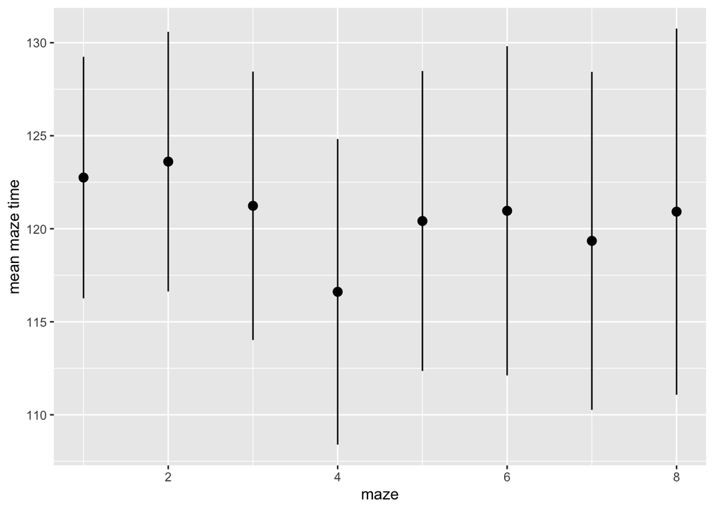